# Cranberries and Heat Stress: Acute Heat Pulse Experiment

STAT 628 — Part 1 yield analysis

Group project

Fall 2026

# Summary

This report analyses the **acute heat-pulse experiment**. The experiment applied 2-hour, 40 °C heat pulses to cranberry plots in two fields (cultivars Mullica Queen, MQ, and Stevens, ST) in 2024 and 2025. Treatments A, B, C and D received 4, 3, 2 and 1 pulses, respectively. Each treated plot was paired with a nearby control plot that received the same insulated open-top chamber (OTC) without heat lamps. The four yield outcomes are total fruit weight, healthy fruit weight, healthy percentage by count, and healthy percentage by weight.

**Main findings.** Heat stress reduced every yield measure (all p < 0.001):

| Outcome | Control | Heat-treated | Effect (95% CI) |
| --- | --- | --- | --- |
| Total weight | 808 g | 715 g | ratio 0.885 (0.834–0.939); −11.5% |
| Healthy weight | 789 g | 634 g | ratio 0.804 (0.749–0.862); −19.6% |
| Healthy % by count | 95.4% | 83.2% | −12.2 pp (−14.6, −9.8); OR 0.24 |
| Healthy % by weight | 98.0% | 89.3% | −8.6 pp (−10.5, −6.8); OR 0.17 |

*Weight entries are model-based geometric means; the raw arithmetic means are 882 vs 784 g (total) and 859 vs 697 g (healthy).*

The effect on **healthy weight** is larger than on total weight because heat also increased rotten weight. The effect on the **weight outcomes grows with the number of heat pulses** (total weight: about −9% per additional pulse, p = 0.002), while the effect on the **percentage outcomes is roughly constant** across A–D. The heat effect on weight was larger in MQ than in ST (interaction p = 0.04), but the percentage outcomes were affected similarly in both cultivars. There was no strong evidence that the heat effect differed between 2024 and 2025. Control plots did not differ across intensity groups (all p > 0.10), supporting the common-control analysis used here.

# Scientific questions and data

This report focuses on the acute heat-pulse experiment. The long-term experiment uses a different design (sets of plot pairs) and is analysed separately. The data and results are confidential and are used here only for the STAT 628 class project.

The assignment asks:

1. How does heat stress affect yield measured by **total weight** of fruit?
2. How does heat stress affect yield measured by **total weight of healthy fruit**?
3. How does heat stress affect yield measured by the **percentage of healthy fruit by count**?
4. How does heat stress affect yield measured by the **percentage of healthy fruit by weight**?
5. How do **cultivar**, **year**, and **intensity of the heat shocks** affect these outcomes?

The modelling questions are: which model is appropriate for each response, how should the plot-pair design be accounted for, and which interactions matter.

```r
d_raw <- read.csv(params$data_file, stringsAsFactors = FALSE)

d <- d_raw %>%
  mutate(
    year             = factor(year),
    cultivar         = factor(toupper(trimws(cultivar))),
    intensity_group  = factor(toupper(trimws(intensity_group)),
                              levels = c("D", "C", "B", "A")),
    treatment        = factor(toupper(trimws(treatment)),
                              levels = c("CONTROL", "OTC"),
                              labels = c("Control", "OTC")),
    pair             = interaction(year, cultivar, intensity_group, plot,
                                   drop = TRUE),
    total_weight     = healthy_weight + rotten_weight,
    healthy_count_pct = 100 * healthy_n / (healthy_n + rotten_n),
    healthy_weight_prop = healthy_weight / total_weight,
    healthy_weight_pct  = 100 * healthy_weight_prop,
    pulses           = as.numeric(c(A = 4, B = 3, C = 2, D = 1)[
                                     as.character(intensity_group)])
  )

# Design checks: 96 plots = 48 pairs; each pair has one Control and one OTC.
stopifnot(nrow(d) == 96, nlevels(d$pair) == 48)
pair_n <- d %>% count(pair) %>% pull(n)
stopifnot(all(pair_n == 2))
pair_ok <- d %>%
  group_by(pair) %>%
  summarise(ok = setequal(as.character(treatment), c("Control", "OTC")),
            .groups = "drop") %>%
  pull(ok)
stopifnot(all(pair_ok))

d %>% distinct(pair, year, cultivar, intensity_group) %>%
  count(year, cultivar, intensity_group) %>%
  pivot_wider(names_from = intensity_group, values_from = n) %>%
  arrange(year, cultivar) %>%
  kable(caption = "Number of plot pairs in each year x cultivar x intensity cell.")
```

Number of plot pairs in each year x cultivar x intensity cell.

| year | cultivar | D | C | B | A |
| --- | --- | --- | --- | --- | --- |
| 2024 | MQ | 3 | 3 | 3 | 3 |
| 2024 | ST | 3 | 3 | 3 | 3 |
| 2025 | MQ | 3 | 3 | 3 | 3 |
| 2025 | ST | 3 | 3 | 3 | 3 |

The data are balanced: 3 pairs per year × cultivar × intensity cell, 48 pairs in total. The `pair` identifier is `year × cultivar × intensity × plot`; the control and treated plots in a pair share the same plot number, so `plot` is a block identifier within a cell, not a unique physical plot identifier.

# Design and exploratory analysis

The experiment is a **randomised block design with plot pairs**: treatment (Control vs OTC) varies *within* a pair, while cultivar, year, and intensity vary *between* pairs. The pairing is the key design feature. A model that ignores it would treat the two plots in a pair as independent and would overstate precision. Conversely, a model that includes a pair effect estimates the heat effect from the **within-pair contrast**, which is the design-based comparison.

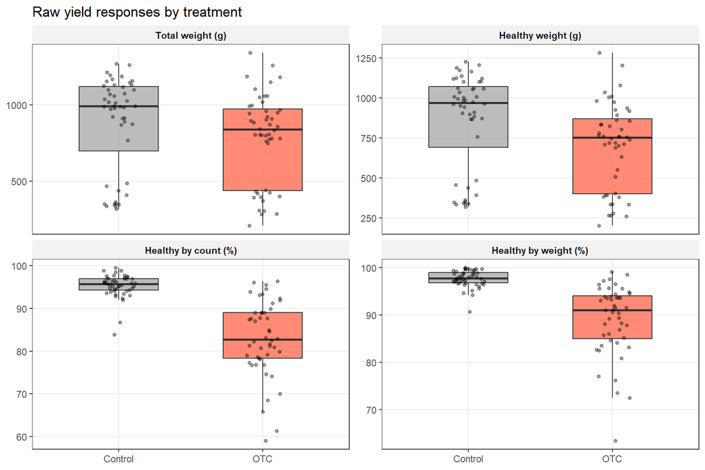

Figure 1. Raw distributions of the four yield outcomes by treatment. Each point is a plot; boxes show medians and quartiles.

```r
d_long <- d %>%
  select(year, cultivar, intensity_group, treatment,
         total_weight, healthy_weight, healthy_count_pct, healthy_weight_pct) %>%
  pivot_longer(
    cols = c(total_weight, healthy_weight, healthy_count_pct, healthy_weight_pct),
    names_to = "response", values_to = "value"
  ) %>%
  mutate(response = factor(
    response,
    levels = c("total_weight", "healthy_weight", "healthy_count_pct", "healthy_weight_pct"),
    labels = c("Total weight (g)", "Healthy weight (g)",
               "Healthy by count (%)", "Healthy by weight (%)")
  ))

ggplot(d_long, aes(x = treatment, y = value, fill = treatment)) +
  geom_boxplot(width = 0.55, outlier.shape = NA, alpha = 0.75) +
  geom_jitter(width = 0.12, alpha = 0.4, size = 1.2) +
  facet_wrap(~ response, scales = "free_y", ncol = 2) +
  scale_fill_manual(values = c("Control" = "grey65", "OTC" = "tomato")) +
  labs(x = NULL, y = NULL, title = "Raw yield responses by treatment") +
  theme_report() +
  theme(legend.position = "none")
```

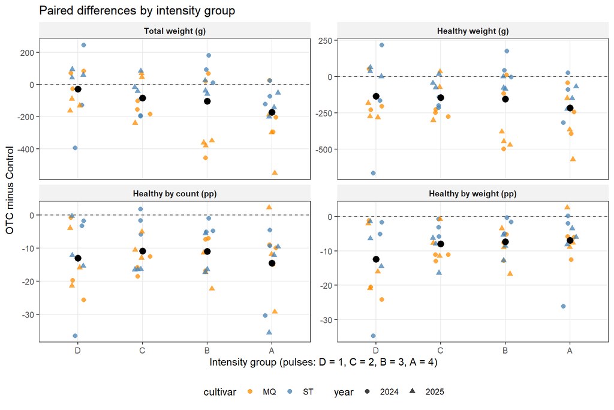

Figure 2. Within-pair differences (OTC minus Control) by intensity group. Each point is one plot pair; the black point is the mean difference. Negative values indicate lower yield under heat.

```r
d_diff <- d %>%
  select(pair, year, cultivar, intensity_group, treatment,
         total_weight, healthy_weight, healthy_count_pct, healthy_weight_pct) %>%
  pivot_longer(
    cols = c(total_weight, healthy_weight, healthy_count_pct, healthy_weight_pct),
    names_to = "response", values_to = "value"
  ) %>%
  pivot_wider(names_from = treatment, values_from = value) %>%
  mutate(
    diff = OTC - Control,
    response = factor(
      response,
      levels = c("total_weight", "healthy_weight", "healthy_count_pct", "healthy_weight_pct"),
      labels = c("Total weight (g)", "Healthy weight (g)",
                 "Healthy by count (pp)", "Healthy by weight (pp)")
    )
  )

ggplot(d_diff, aes(x = intensity_group, y = diff)) +
  geom_hline(yintercept = 0, linetype = 2, colour = "grey35") +
  geom_point(aes(colour = cultivar, shape = year),
             position = position_jitter(width = 0.12, height = 0),
             alpha = 0.75, size = 2) +
  stat_summary(fun = mean, geom = "point", colour = "black", size = 3) +
  facet_wrap(~ response, scales = "free_y", ncol = 2) +
  scale_colour_manual(values = c(MQ = "darkorange", ST = "steelblue")) +
  labs(
    x = "Intensity group (pulses: D = 1, C = 2, B = 3, A = 4)",
    y = "OTC minus Control",
    title = "Paired differences by intensity group"
  ) +
  theme_report()
```

Figure 1 shows that the heat-treated plots have lower total and healthy weights and lower healthy percentages. Figure 2 shows the paired differences: the weight differences become more negative as the number of pulses increases, whereas the percentage differences are already large at one pulse and do not change much thereafter. This is the main pattern that the models below quantify.

# Model specification

## Response types and model families

The four responses need different models:

| Response | Scale | Model | Random effect | Why |
| --- | --- | --- | --- | --- |
| Total weight | positive continuous, right-skewed | log-normal LMM (`lmer`) | `(1 \| pair)` | variance grows with the mean; log stabilises it |
| Healthy weight | positive continuous, right-skewed | log-normal LMM (`lmer`) | `(1 \| pair)` | same |
| Healthy % by count | binomial proportion with overdispersion | beta-binomial GLMM, logit (`glmmTMB`) | `(1 \| pair)` | counts; extra-binomial variation |
| Healthy % by weight | continuous proportion in (0, 1) | beta GLMM, logit (`glmmTMB`) | `(1 \| pair)` | bounded response; variance differs by treatment |

For the weights, a Gamma GLMM with a log link is an alternative; it is used as a sensitivity analysis. For the count percentage, a binomial GLMM with an observation-level random effect is also possible; it is compared with the beta-binomial in the sensitivity section.

## Fixed effects

All four models use the same fixed-effect structure:

```r
y ~ treatment * (intensity_group + cultivar + year) + year:cultivar + (1 | pair)
```

The terms have specific roles:

- `treatment` is the **heat effect** (OTC vs Control). Because treatment varies within a pair, this is a within-pair contrast.
- `intensity_group` is the pulse-frequency treatment (A = 4, B = 3, C = 2, D = 1 pulses). For control plots, intensity is the intensity of the paired treatment; the main effect therefore measures whether **control plots differ across intensity groups**. This is a direct check of the common-control assumption.
- `cultivar`, `year`, and `year:cultivar` describe baseline differences between fields and seasons.
- `treatment:intensity_group` asks whether the heat effect depends on the number of pulses (Question 5).
- `treatment:cultivar` asks whether the heat effect differs between MQ and ST (Question 5).
- `treatment:year` asks whether the heat effect differs between 2024 and 2025 (Question 5).

We keep the baseline structure to year × cultivar and do not add intensity × cultivar or intensity × year baseline terms: intensity is a between-pair factor with only three pairs per cell, and these terms are not required for the heat-effect questions. The treatment interactions above are the terms that answer Question 5.

The pair random intercept `(1 | pair)` accounts for the correlation between the control and treated plots in the same pair. This is the model-based analogue of a paired analysis: the treatment effect is estimated from the within-pair difference, while the pair intercept absorbs between-pair variation in soil, position, and plant material.

## Estimation and inference

The LMMs are fitted by REML and the GLMMs by maximum likelihood. Fixed-effect tests use likelihood-ratio tests (`drop1`); Kenward–Roger degrees of freedom are used for the LMM contrasts and asymptotic Wald tests for the GLMMs. Estimated marginal means (EMMs) are averaged with equal weights over the observed design (3 pairs per cell), so the overall heat effect is the average over years, cultivars, and intensity groups. Confidence intervals are pointwise 95%. The four outcomes are correlated (they are computed from the same fruit), so they are not independent evidence; effect sizes and intervals are more informative than a strict multiplicity threshold.

Because the weight models are fitted on the log scale, their response-scale EMMs are geometric means. For comparison, the raw arithmetic means are 882 vs 784 g for total weight and 859 vs 697 g for healthy weight; the ratio and percentage-change estimates are unaffected by this distinction.

```r
fit_total <- lmer(
  log(total_weight) ~ treatment * (intensity_group + cultivar + year) +
    year:cultivar + (1 | pair),
  data = d, REML = TRUE
)

fit_healthy <- lmer(
  log(healthy_weight) ~ treatment * (intensity_group + cultivar + year) +
    year:cultivar + (1 | pair),
  data = d, REML = TRUE
)

fit_count <- glmmTMB(
  cbind(healthy_n, rotten_n) ~ treatment * (intensity_group + cultivar + year) +
    year:cultivar + (1 | pair),
  data = d, family = betabinomial(link = "logit"),
  dispformula = ~ treatment
)

fit_wpct <- glmmTMB(
  healthy_weight_prop ~ treatment * (intensity_group + cultivar + year) +
    year:cultivar + (1 | pair),
  data = d, family = beta_family(link = "logit"),
  dispformula = ~ treatment
)
```

# Do the heat effects depend on cultivar, year, or intensity?

The interaction tests answer Question 5 and also determine how the overall effects in Questions 1–4 should be read.

```r
tidy_drop1 <- function(fit, response) {
  a <- drop1(fit, test = "Chisq")
  a <- a[rownames(a) != "<none>", , drop = FALSE]
  df <- if ("Chi Df" %in% names(a)) {
    a[["Chi Df"]]
  } else if ("Df" %in% names(a)) {
    a[["Df"]]
  } else {
    a[["npar"]]
  }
  data.frame(
    Response = response,
    Term = rownames(a),
    df = df,
    LRT = a[["LRT"]],
    p = if ("Pr(Chi)" %in% names(a)) a[["Pr(Chi)"]] else a[["Pr(>Chi)"]],
    row.names = NULL
  )
}

lrt_tab <- bind_rows(
  tidy_drop1(fit_total,   "Total weight"),
  tidy_drop1(fit_healthy, "Healthy weight"),
  tidy_drop1(fit_count,   "Healthy by count"),
  tidy_drop1(fit_wpct,    "Healthy by weight")
) %>%
  mutate(
    Term = recode(Term,
                  "treatment:intensity_group" = "Heat x intensity",
                  "treatment:cultivar"        = "Heat x cultivar",
                  "treatment:year"            = "Heat x year",
                  "cultivar:year"             = "Cultivar x year"),
    p = fmt_p(p)
  )

kable(lrt_tab, caption = "Likelihood-ratio tests for the interaction terms.",
      align = c("l", "l", "r", "r", "r"))
```

Likelihood-ratio tests for the interaction terms.

| Response | Term | df | LRT | p |
| --- | --- | --- | --- | --- |
| Total weight | Heat x intensity | 3 | 11.8061084 | 0.008 |
| Total weight | Heat x cultivar | 1 | 4.0677290 | 0.044 |
| Total weight | Heat x year | 1 | 2.2086153 | 0.137 |
| Total weight | Cultivar x year | 1 | 75.7134468 | <0.001 |
| Healthy weight | Heat x intensity | 3 | 5.9635953 | 0.113 |
| Healthy weight | Heat x cultivar | 1 | 4.1902679 | 0.041 |
| Healthy weight | Heat x year | 1 | 1.1619257 | 0.281 |
| Healthy weight | Cultivar x year | 1 | 68.5043545 | <0.001 |
| Healthy by count | Heat x intensity | 3 | 3.4817663 | 0.323 |
| Healthy by count | Heat x cultivar | 1 | 0.3770625 | 0.539 |
| Healthy by count | Heat x year | 1 | 0.7875147 | 0.375 |
| Healthy by count | Cultivar x year | 1 | 0.1132378 | 0.736 |
| Healthy by weight | Heat x intensity | 3 | 1.1337704 | 0.769 |
| Healthy by weight | Heat x cultivar | 1 | 3.1980260 | 0.074 |
| Healthy by weight | Heat x year | 1 | 0.5006497 | 0.479 |
| Healthy by weight | Cultivar x year | 1 | 0.1426388 | 0.706 |

# Questions 1–4: overall effect of heat stress

For each response, the overall heat effect is the EMM contrast between OTC and Control, averaged over the observed years, cultivars, and intensity groups. For the weights, the contrast is reported as a ratio (OTC / Control) and a percentage change; for the percentages, as a difference in percentage points (pp) and an odds ratio.

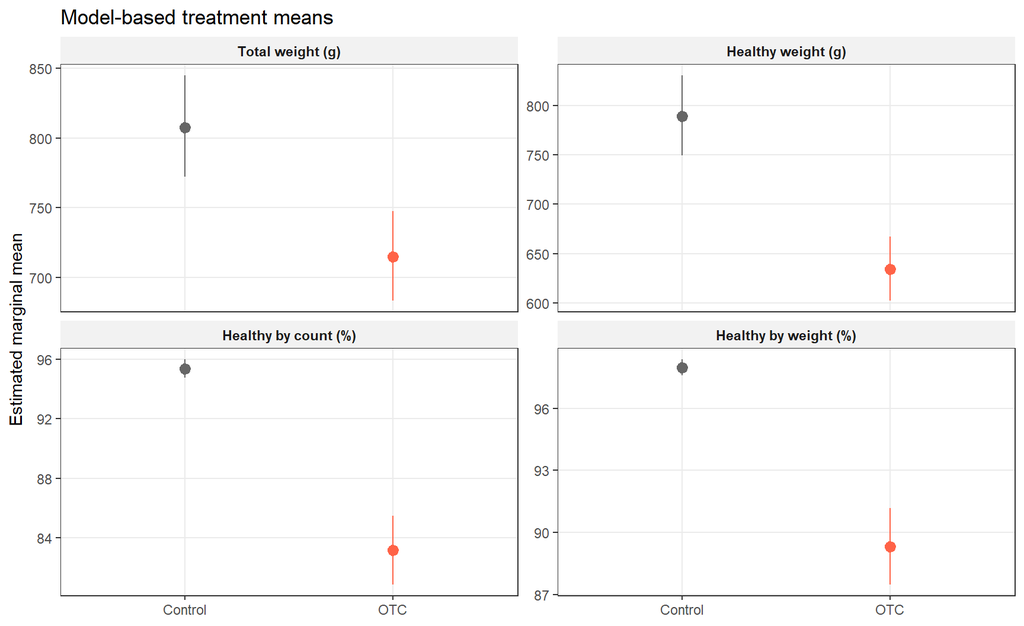

Figure 3. Model-based marginal means (95% CI) for Control and heat-treated plots, averaged over years, cultivars, and intensity groups.

```r
emm_one <- function(fit, response, type = c("weight", "proportion")) {
  type <- match.arg(type)
  em <- if (type == "weight") {
    emmeans(fit, ~ treatment, type = "response")
  } else {
    regrid(emmeans(fit, ~ treatment), "response")
  }
  s <- as.data.frame(summary(em))
  est_name <- setdiff(names(s), c("treatment", "SE", "df",
                                  "lower.CL", "upper.CL",
                                  "asymp.LCL", "asymp.UCL"))[1]
  lo_name <- names(s)[grepl("lower|LCL", names(s))][1]
  hi_name <- names(s)[grepl("upper|UCL", names(s))][1]
  mult <- if (type == "proportion") 100 else 1
  data.frame(
    response = response,
    treatment = s$treatment,
    estimate = mult * s[[est_name]],
    lower = mult * s[[lo_name]],
    upper = mult * s[[hi_name]],
    stringsAsFactors = FALSE
  )
}

overall_emm <- bind_rows(
  emm_one(fit_total,   "Total weight (g)",          "weight"),
  emm_one(fit_healthy, "Healthy weight (g)",        "weight"),
  emm_one(fit_count,   "Healthy by count (%)",      "proportion"),
  emm_one(fit_wpct,    "Healthy by weight (%)",     "proportion")
)
overall_emm$response <- factor(
  overall_emm$response,
  levels = c("Total weight (g)", "Healthy weight (g)",
             "Healthy by count (%)", "Healthy by weight (%)")
)

ggplot(overall_emm, aes(x = treatment, y = estimate, colour = treatment)) +
  geom_pointrange(aes(ymin = lower, ymax = upper), size = 0.6) +
  facet_wrap(~ response, scales = "free_y", ncol = 2) +
  scale_colour_manual(values = c("Control" = "grey40", "OTC" = "tomato")) +
  labs(x = NULL, y = "Estimated marginal mean",
       title = "Model-based treatment means") +
  theme_report() +
  theme(legend.position = "none")
```

```r
overall_row <- function(fit, response, type = c("weight", "proportion")) {
  type <- match.arg(type)
  if (type == "weight") {
    em <- emmeans(fit, ~ treatment, type = "response")
    s <- as.data.frame(summary(em))
    ct_full <- contrast(emmeans(fit, ~ treatment),
                        "revpairwise", type = "response")
    ct <- as.data.frame(confint(ct_full))
    p  <- as.data.frame(summary(ct_full))$p.value
    data.frame(
      Response = response,
      Control = sprintf("%.0f (%.0f, %.0f)", s$response[1], s$lower.CL[1], s$upper.CL[1]),
      OTC = sprintf("%.0f (%.0f, %.0f)", s$response[2], s$lower.CL[2], s$upper.CL[2]),
      Effect = sprintf("%.2f (%.2f, %.2f); %.1f%%", ct$ratio, ct$lower.CL,
                       ct$upper.CL, 100 * (ct$ratio - 1)),
      p = fmt_p(p),
      stringsAsFactors = FALSE
    )
  } else {
    em <- regrid(emmeans(fit, ~ treatment), "response")
    s <- as.data.frame(summary(em))
    ct_full <- contrast(em, "revpairwise")
    ct <- as.data.frame(confint(ct_full))
    p  <- as.data.frame(summary(ct_full))$p.value
    or <- as.data.frame(confint(contrast(emmeans(fit, ~ treatment),
                                         "revpairwise", type = "response")))
    est_name <- setdiff(names(s), c("treatment", "SE", "df",
                                    "lower.CL", "upper.CL",
                                    "asymp.LCL", "asymp.UCL"))[1]
    data.frame(
      Response = response,
      Control = sprintf("%.1f (%.1f, %.1f)", 100 * s[[est_name]][1],
                        100 * s$asymp.LCL[1], 100 * s$asymp.UCL[1]),
      OTC = sprintf("%.1f (%.1f, %.1f)", 100 * s[[est_name]][2],
                    100 * s$asymp.LCL[2], 100 * s$asymp.UCL[2]),
      Effect = sprintf("%+.1f pp (%.1f, %.1f); OR %.2f", 100 * ct$estimate,
                       100 * ct$asymp.LCL, 100 * ct$asymp.UCL, or$odds.ratio),
      p = fmt_p(p),
      stringsAsFactors = FALSE
    )
  }
}

overall_tab <- bind_rows(
  overall_row(fit_total,   "Total weight (g)",      "weight"),
  overall_row(fit_healthy, "Healthy weight (g)",    "weight"),
  overall_row(fit_count,   "Healthy by count (%)",  "proportion"),
  overall_row(fit_wpct,    "Healthy by weight (%)", "proportion")
)

kable(overall_tab,
      caption = "Overall heat effect (OTC vs Control), averaged over years, cultivars, and intensity groups. Weights: ratio and percentage change. Percentages: percentage-point difference and odds ratio.",
      align = c("l", "l", "l", "l", "r"))
```

Overall heat effect (OTC vs Control), averaged over years, cultivars, and intensity groups. Weights: ratio and percentage change. Percentages: percentage-point difference and odds ratio.

| Response | Control | OTC | Effect | p |
| --- | --- | --- | --- | --- |
| Total weight (g) | 808 (772, 845) | 715 (683, 748) | 0.88 (0.83, 0.94); -11.5% | <0.001 |
| Healthy weight (g) | 789 (750, 831) | 634 (602, 667) | 0.80 (0.75, 0.86); -19.6% | <0.001 |
| Healthy by count (%) | 95.4 (94.8, 96.0) | 83.2 (80.8, 85.5) | -12.2 pp (-14.6, -9.8); OR 0.24 | <0.001 |
| Healthy by weight (%) | 98.0 (97.6, 98.4) | 89.3 (87.5, 91.2) | -8.6 pp (-10.5, -6.8); OR 0.17 | <0.001 |

## Question 1: total fruit weight

Heat stress reduced total fruit weight by about **11.5%** (ratio 0.885, 95% CI 0.834–0.939; p < 0.001). The EMMs are 808 g for Control and 715 g for OTC, a difference of about 93 g. Because total weight includes rotten fruit, this effect is smaller than the effect on healthy weight: heat increased rotten weight, which partly offsets the loss of healthy fruit.

## Question 2: healthy fruit weight

Heat stress reduced healthy fruit weight by about **19.6%** (ratio 0.804, 95% CI 0.749–0.862; p < 0.001). The EMMs are 789 g for Control and 634 g for OTC, a difference of about 155 g. This is the largest absolute effect among the four outcomes and is the most direct measure of marketable yield.

## Question 3: healthy percentage by count

Heat stress reduced the healthy percentage by count by **12.2 percentage points**, from 95.4% to 83.2% (95% CI −14.6 to −9.8 pp; odds ratio 0.24, 95% CI 0.19–0.30; p < 0.001). The odds ratio is far from 1 because the control percentage is near the ceiling: a 12-point drop from 95% corresponds to a large change on the odds scale.

## Question 4: healthy percentage by weight

Heat stress reduced the healthy percentage by weight by **8.6 percentage points**, from 98.0% to 89.3% (95% CI −10.5 to −6.8 pp; odds ratio 0.17, 95% CI 0.13–0.23; p < 0.001). The count-based and weight-based percentages tell a consistent story, although the count-based measure is more sensitive (12.2 vs 8.6 pp), indicating that heat increases the number of rotten berries somewhat more than their share of weight.

# Question 5: cultivar, year, and intensity

## Intensity of the heat shocks

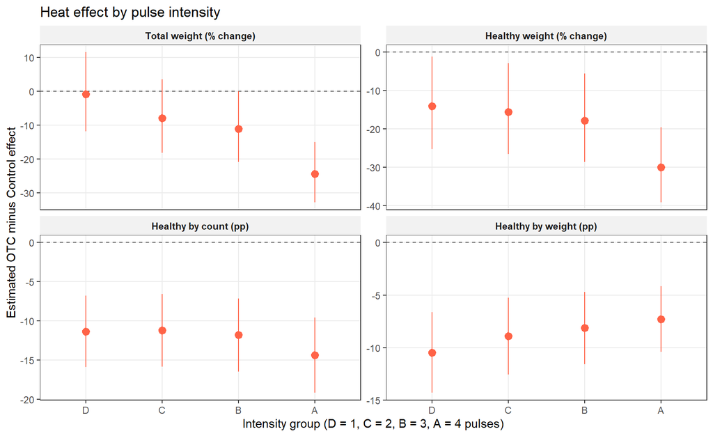

Figure 4. Estimated heat effect (OTC minus Control) by intensity group, with pointwise 95% CIs. Weight outcomes are shown as percentage change; percentage outcomes as percentage-point differences.

```r
effect_by_intensity <- function(fit, response, type = c("weight", "proportion")) {
  type <- match.arg(type)
  em <- emmeans(fit, ~ treatment | intensity_group)
  if (type == "weight") {
    ct <- as.data.frame(confint(contrast(em, "revpairwise", type = "response")))
    est <- 100 * (ct$ratio - 1)
    lo  <- 100 * (ct$lower.CL - 1)
    hi  <- 100 * (ct$upper.CL - 1)
  } else {
    ct <- as.data.frame(confint(contrast(regrid(em, "response"), "revpairwise")))
    est <- 100 * ct$estimate
    lo  <- 100 * ct$asymp.LCL
    hi  <- 100 * ct$asymp.UCL
  }
  data.frame(
    response = response,
    intensity = ct$intensity_group,
    estimate = est, lower = lo, upper = hi,
    stringsAsFactors = FALSE
  )
}

intensity_eff <- bind_rows(
  effect_by_intensity(fit_total,   "Total weight (% change)",      "weight"),
  effect_by_intensity(fit_healthy, "Healthy weight (% change)",    "weight"),
  effect_by_intensity(fit_count,   "Healthy by count (pp)",        "proportion"),
  effect_by_intensity(fit_wpct,    "Healthy by weight (pp)",       "proportion")
)
intensity_eff$response <- factor(
  intensity_eff$response,
  levels = c("Total weight (% change)", "Healthy weight (% change)",
             "Healthy by count (pp)", "Healthy by weight (pp)")
)

ggplot(intensity_eff, aes(x = intensity, y = estimate)) +
  geom_hline(yintercept = 0, linetype = 2, colour = "grey35") +
  geom_pointrange(aes(ymin = lower, ymax = upper), colour = "tomato", size = 0.6) +
  facet_wrap(~ response, scales = "free_y", ncol = 2) +
  labs(
    x = "Intensity group (D = 1, C = 2, B = 3, A = 4 pulses)",
    y = "Estimated OTC minus Control effect",
    title = "Heat effect by pulse intensity"
  ) +
  theme_report()
```

```r
intensity_cell <- function(fit, response, type = c("weight", "proportion")) {
  type <- match.arg(type)
  em <- emmeans(fit, ~ treatment | intensity_group)
  if (type == "weight") {
    ct <- as.data.frame(confint(contrast(em, "revpairwise", type = "response")))
    cell <- sprintf("%.1f%% (%.1f, %.1f)", 100 * (ct$ratio - 1),
                    100 * (ct$lower.CL - 1), 100 * (ct$upper.CL - 1))
  } else {
    ct <- as.data.frame(confint(contrast(regrid(em, "response"), "revpairwise")))
    cell <- sprintf("%+.1f pp (%.1f, %.1f)", 100 * ct$estimate,
                    100 * ct$asymp.LCL, 100 * ct$asymp.UCL)
  }
  data.frame(response = response, intensity = ct$intensity_group, cell = cell,
             stringsAsFactors = FALSE) %>%
    pivot_wider(names_from = intensity, values_from = cell)
}

intensity_tab <- bind_rows(
  intensity_cell(fit_total,   "Total weight",      "weight"),
  intensity_cell(fit_healthy, "Healthy weight",    "weight"),
  intensity_cell(fit_count,   "Healthy by count",  "proportion"),
  intensity_cell(fit_wpct,    "Healthy by weight", "proportion")
) %>%
  mutate(across(c(D, C, B, A), ~ replace_na(.x, "")))

kable(intensity_tab,
      caption = "Heat effect by intensity group (95% CI). Weights are percentage changes; percentages are percentage-point differences.",
      align = c("l", "l", "l", "l", "l"))
```

Heat effect by intensity group (95% CI). Weights are percentage changes; percentages are percentage-point differences.

| response | D | C | B | A |
| --- | --- | --- | --- | --- |
| Total weight | -0.8% (-11.8, 11.6) | -7.9% (-18.1, 3.6) | -11.1% (-20.9, 0.0) | -24.5% (-32.9, -15.1) |
| Healthy weight | -14.0% (-25.3, -1.2) | -15.5% (-26.6, -2.9) | -17.9% (-28.6, -5.5) | -30.0% (-39.2, -19.5) |
| Healthy by count | -11.3 pp (-15.9, -6.8) | -11.2 pp (-15.9, -6.5) | -11.8 pp (-16.5, -7.1) | -14.4 pp (-19.2, -9.6) |
| Healthy by weight | -10.5 pp (-14.3, -6.6) | -8.9 pp (-12.5, -5.2) | -8.1 pp (-11.6, -4.7) | -7.3 pp (-10.4, -4.2) |

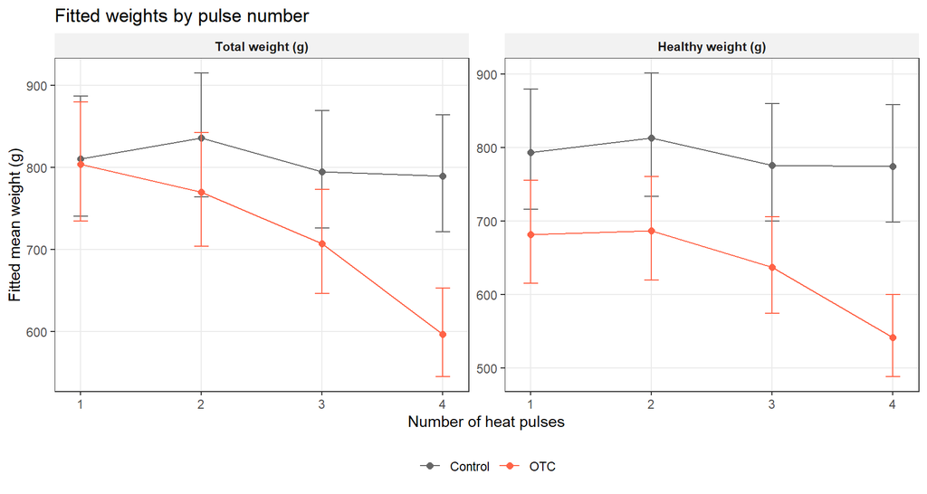

Figure 5. Fitted mean total and healthy weight by treatment and number of heat pulses. Points are EMMs and bars are pointwise 95% CIs. The lines connect fitted means and are not a fitted trend.

```r
dose_df <- bind_rows(
  as.data.frame(summary(emmeans(fit_total, ~ treatment | intensity_group,
                                type = "response"))) %>%
    rename(emmean = response) %>%
    mutate(response = "Total weight (g)"),
  as.data.frame(summary(emmeans(fit_healthy, ~ treatment | intensity_group,
                                type = "response"))) %>%
    rename(emmean = response) %>%
    mutate(response = "Healthy weight (g)")
) %>%
  mutate(
    pulses = as.numeric(c(D = 1, C = 2, B = 3, A = 4)[
      as.character(intensity_group)]),
    response = factor(response,
                      levels = c("Total weight (g)", "Healthy weight (g)"))
  )

ggplot(dose_df, aes(x = pulses, y = emmean, colour = treatment)) +
  geom_line() +
  geom_point(size = 2) +
  geom_errorbar(aes(ymin = lower.CL, ymax = upper.CL), width = 0.12) +
  facet_wrap(~ response, scales = "free_y") +
  scale_colour_manual(values = c("Control" = "grey40", "OTC" = "tomato")) +
  scale_x_continuous(breaks = 1:4) +
  labs(x = "Number of heat pulses", y = "Fitted mean weight (g)",
       colour = NULL, title = "Fitted weights by pulse number") +
  theme_report()
```

The intensity pattern differs between the weight and percentage outcomes:

- **Total weight**: the effect rises steadily with the number of pulses, from −0.8% at D (1 pulse, not significant) to −24.5% at A (4 pulses). The linear pulse trend is −9.3% per additional pulse (95% CI −12.9% to −5.7%, p = 0.002).
- **Healthy weight**: the effect also rises with intensity, from −14.0% at D to −30.0% at A; the linear trend is −7.4% per pulse (95% CI −11.5% to −3.1%, p = 0.041).
- **Healthy % by count**: the effect is already large at D (−11.3 pp) and changes little across D–A (−11.2 to −14.4 pp). The intensity effect is not significant (p = 0.323).
- **Healthy % by weight**: the effect is actually largest at D (−10.5 pp) and smallest at A (−7.3 pp), but the differences are not significant (p = 0.769). This ordering is the opposite of the weight outcomes and should not be over-interpreted; with three pairs per cell, the D estimate is imprecise and may be influenced by a few high-rot plots.

A useful decomposition is the **joint test of intensity within each treatment**. Among control plots, intensity has no effect on any outcome (total weight F = 0.32, p = 0.81; healthy weight F = 0.20, p = 0.90; count percentage p = 0.11; weight percentage p = 0.14). Among OTC plots, intensity matters for total weight (F = 8.53, p < 0.001) and healthy weight (F = 4.58, p = 0.005), but not for the percentage outcomes (p = 0.91 and p = 0.43). This supports two conclusions: the control plots are comparable across intensity groups (so pooling them is reasonable), and the pulse-intensity effect is specific to the weight outcomes.

## Cultivar and year

```r
modifier_cell <- function(fit, response, by, type = c("weight", "proportion")) {
  type <- match.arg(type)
  em <- emmeans(fit, as.formula(paste("~ treatment |", by)))
  if (type == "weight") {
    ct <- as.data.frame(confint(contrast(em, "revpairwise", type = "response")))
    cell <- sprintf("%.2f (%.2f, %.2f)", ct$ratio, ct$lower.CL, ct$upper.CL)
  } else {
    ct <- as.data.frame(confint(contrast(regrid(em, "response"), "revpairwise")))
    cell <- sprintf("%+.1f pp (%.1f, %.1f)", 100 * ct$estimate,
                    100 * ct$asymp.LCL, 100 * ct$asymp.UCL)
  }
  data.frame(response = response, level = ct[[by]], cell = cell,
             stringsAsFactors = FALSE)
}

cultivar_tab <- bind_rows(
  modifier_cell(fit_total,   "Total weight",      "cultivar", "weight"),
  modifier_cell(fit_healthy, "Healthy weight",    "cultivar", "weight"),
  modifier_cell(fit_count,   "Healthy by count",  "cultivar", "proportion"),
  modifier_cell(fit_wpct,    "Healthy by weight", "cultivar", "proportion")
) %>%
  pivot_wider(names_from = level, values_from = cell)

year_tab <- bind_rows(
  modifier_cell(fit_total,   "Total weight",      "year", "weight"),
  modifier_cell(fit_healthy, "Healthy weight",    "year", "weight"),
  modifier_cell(fit_count,   "Healthy by count",  "year", "proportion"),
  modifier_cell(fit_wpct,    "Healthy by weight", "year", "proportion")
) %>%
  pivot_wider(names_from = level, values_from = cell)

kable(cultivar_tab,
      caption = "Heat effect by cultivar (95% CI). Weights: ratio (OTC/Control); percentages: percentage-point difference.",
      align = c("l", "l", "l"))
```

Heat effect by cultivar (95% CI). Weights: ratio (OTC/Control); percentages: percentage-point difference.

| response | MQ | ST |
| --- | --- | --- |
| Total weight | 0.84 (0.77, 0.91) | 0.94 (0.86, 1.02) |
| Healthy weight | 0.75 (0.68, 0.83) | 0.86 (0.78, 0.95) |
| Healthy by count | -13.5 pp (-17.0, -10.1) | -11.0 pp (-14.2, -7.8) |
| Healthy by weight | -10.0 pp (-12.9, -7.2) | -7.3 pp (-9.5, -5.0) |

```r
kable(year_tab,
      caption = "Heat effect by year (95% CI). Weights: ratio (OTC/Control); percentages: percentage-point difference.",
      align = c("l", "l", "l"))
```

Heat effect by year (95% CI). Weights: ratio (OTC/Control); percentages: percentage-point difference.

| response | 2024 | 2025 |
| --- | --- | --- |
| Total weight | 0.92 (0.85, 1.00) | 0.85 (0.78, 0.92) |
| Healthy weight | 0.83 (0.75, 0.92) | 0.78 (0.70, 0.86) |
| Healthy by count | -10.4 pp (-13.5, -7.3) | -14.3 pp (-17.8, -10.7) |
| Healthy by weight | -8.3 pp (-10.8, -5.8) | -9.0 pp (-11.7, -6.4) |

**Cultivar.** The heat effect on weight was larger in MQ than in ST: total weight ratio 0.84 vs 0.94, healthy weight ratio 0.75 vs 0.86 (interaction p = 0.044 and 0.041). The percentage outcomes were affected similarly in the two cultivars (count: −13.5 vs −11.0 pp, p = 0.54; weight: −10.0 vs −7.3 pp, p = 0.074). The cultivar difference for weights could be a genuine varietal difference, but cultivar is completely confounded with field in this experiment, so it could also reflect field, soil, or management differences. The data cannot separate these explanations.

**Year.** The heat effect was somewhat larger in 2025 than in 2024 for total weight (−15.1% vs −7.8%) and count percentage (−14.3 vs −10.4 pp), but the interactions are not significant (p = 0.137 and 0.375). The baseline year × cultivar difference is much larger than any year difference in the heat effect: 2025 ST had a much lower baseline yield than 2024 ST. Year effects in this experiment are therefore primarily baseline/season effects, not evidence that heat sensitivity changed.

# Pulse-number trend

To describe the dose–response more directly, the intensity factor is replaced by the number of pulses (1–4). The `treatment:pulses` term tests whether the heat effect changes linearly with the number of pulses; the control slope is a between-pair baseline trend.

```r
trend_fit <- function(resp, family = c("gaussian", "count", "beta")) {
  family <- match.arg(family)
  f <- as.formula(paste(resp, "~ treatment * (pulses + cultivar + year) +",
                        "year:cultivar + (1 | pair)"))
  if (family == "gaussian") {
    lmer(f, data = d, REML = TRUE)
  } else if (family == "count") {
    glmmTMB(f, data = d, family = betabinomial(link = "logit"),
            dispformula = ~ treatment)
  } else {
    glmmTMB(f, data = d, family = beta_family(link = "logit"),
            dispformula = ~ treatment)
  }
}

tr_total   <- trend_fit("log(total_weight)", "gaussian")
tr_healthy <- trend_fit("log(healthy_weight)", "gaussian")
tr_count   <- trend_fit("cbind(healthy_n, rotten_n)", "count")
tr_wpct    <- trend_fit("healthy_weight_prop", "beta")

trend_row <- function(fit, response) {
  et <- emtrends(fit, ~ treatment, var = "pulses")
  s <- as.data.frame(summary(et))
  lo_name <- names(s)[grepl("lower|LCL", names(s))][1]
  hi_name <- names(s)[grepl("upper|UCL", names(s))][1]
  ct <- as.data.frame(confint(contrast(et, "revpairwise")))
  ct_lo <- names(ct)[grepl("lower|LCL", names(ct))][1]
  ct_hi <- names(ct)[grepl("upper|UCL", names(ct))][1]
  ct_p  <- as.data.frame(summary(contrast(et, "revpairwise")))$p.value
  data.frame(
    Response = response,
    Control = sprintf("%.3f (%.3f, %.3f)", s$pulses.trend[1],
                      s[[lo_name]][1], s[[hi_name]][1]),
    OTC = sprintf("%.3f (%.3f, %.3f)", s$pulses.trend[2],
                  s[[lo_name]][2], s[[hi_name]][2]),
    Difference = sprintf("%.3f (%.3f, %.3f)", ct$estimate,
                         ct[[ct_lo]], ct[[ct_hi]]),
    p = fmt_p(ct_p),
    stringsAsFactors = FALSE
  )
}

trend_tab <- bind_rows(
  trend_row(tr_total,   "Total weight (log)"),
  trend_row(tr_healthy, "Healthy weight (log)"),
  trend_row(tr_count,   "Healthy by count (logit)"),
  trend_row(tr_wpct,    "Healthy by weight (logit)")
)

kable(trend_tab,
      caption = "Estimated change per additional heat pulse. Slopes are on the log (weights) or logit (percentages) scale; the difference is OTC minus Control.",
      align = c("l", "l", "l", "l", "r"))
```

Estimated change per additional heat pulse. Slopes are on the log (weights) or logit (percentages) scale; the difference is OTC minus Control.

| Response | Control | OTC | Difference | p |
| --- | --- | --- | --- | --- |
| Total weight (log) | -0.013 (-0.053, 0.027) | -0.098 (-0.138, -0.058) | -0.085 (-0.137, -0.033) | 0.002 |
| Healthy weight (log) | -0.012 (-0.058, 0.033) | -0.077 (-0.122, -0.031) | -0.064 (-0.126, -0.003) | 0.041 |
| Healthy by count (logit) | 0.051 (-0.073, 0.175) | -0.052 (-0.195, 0.091) | -0.103 (-0.292, 0.086) | 0.284 |
| Healthy by weight (logit) | 0.124 (-0.022, 0.270) | 0.134 (-0.023, 0.291) | 0.010 (-0.205, 0.224) | 0.930 |

On the log scale, the OTC slope for total weight is −0.098 per pulse, i.e. about **−9.3% per additional pulse** (95% CI −12.9% to −5.7%). The control slope is essentially zero (−0.013, 95% CI −0.053 to 0.027), and the difference is significant (p = 0.002). For healthy weight the OTC slope is −0.077 per pulse (about −7.4%, 95% CI −11.5% to −3.1%; difference p = 0.041). For the percentage outcomes the slopes are small and not significant (count p = 0.284; weight p = 0.930). This is the clearest evidence that the weight loss is a **dose–response to the number of heat pulses**, whereas the percentage loss is a **step change** that is already present at one pulse.

# Diagnostics

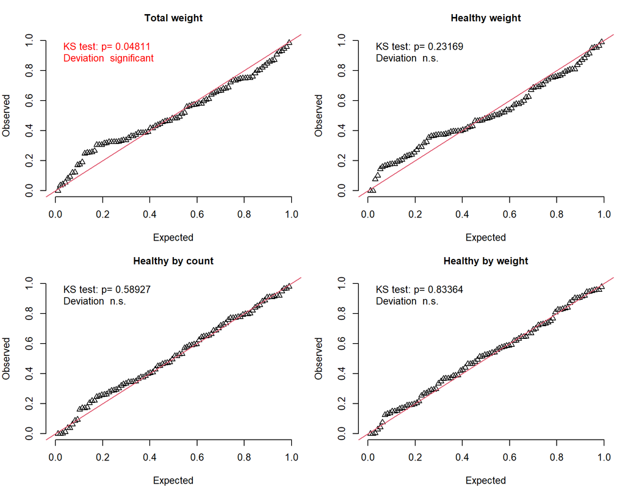

```r
set.seed(628)
diag_list <- list(
  "Total weight"      = fit_total,
  "Healthy weight"    = fit_healthy,
  "Healthy by count"  = fit_count,
  "Healthy by weight" = fit_wpct
)

diag_res <- lapply(diag_list, function(m) simulateResiduals(m, n = 500))

par(mfrow = c(2, 2), mar = c(4, 4, 3, 1))
for (nm in names(diag_res)) {
  plotQQunif(diag_res[[nm]], testDispersion = FALSE,
             testOutliers = FALSE, main = nm)
}
```

```r
diag_tab <- bind_rows(lapply(names(diag_res), function(nm) {
  r <- diag_res[[nm]]
  data.frame(
    Model = nm,
    Dispersion = fmt_p(testDispersion(r)$p.value),
    Uniformity = fmt_p(testUniformity(r)$p.value),
    Outliers = fmt_p(testOutliers(r)$p.value),
    stringsAsFactors = FALSE
  )
}))
```

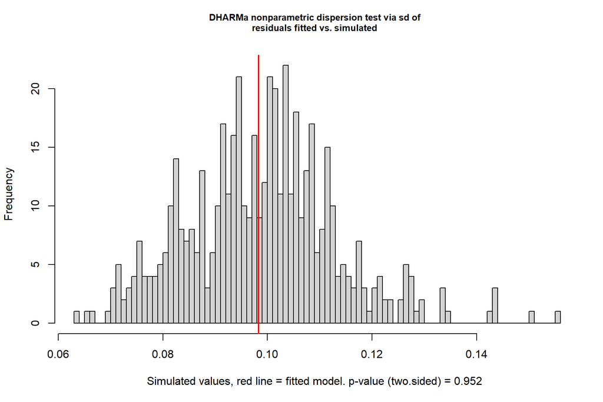

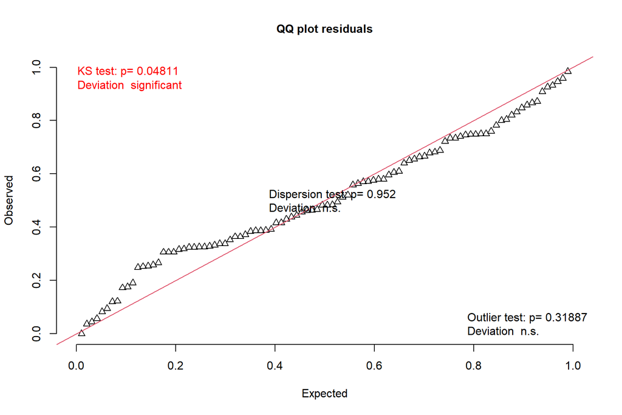

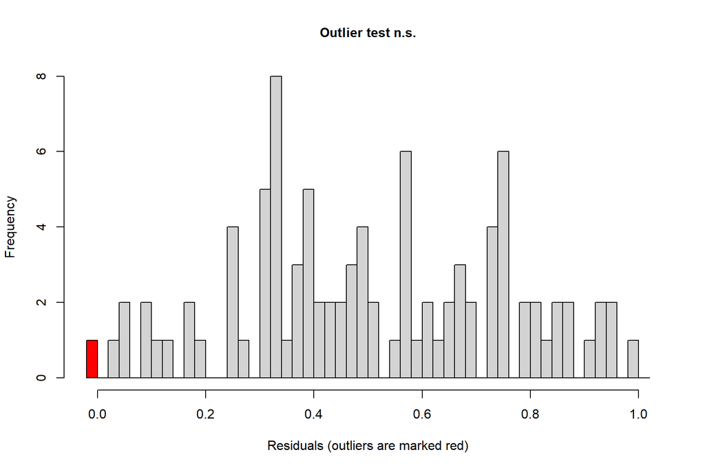

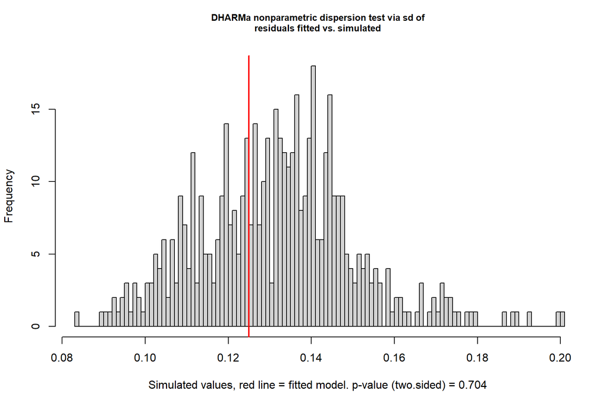

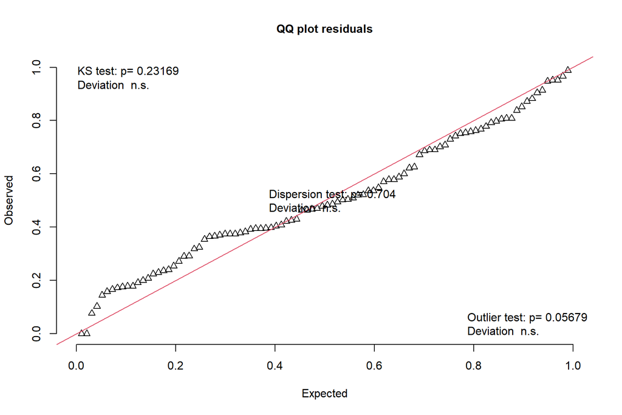

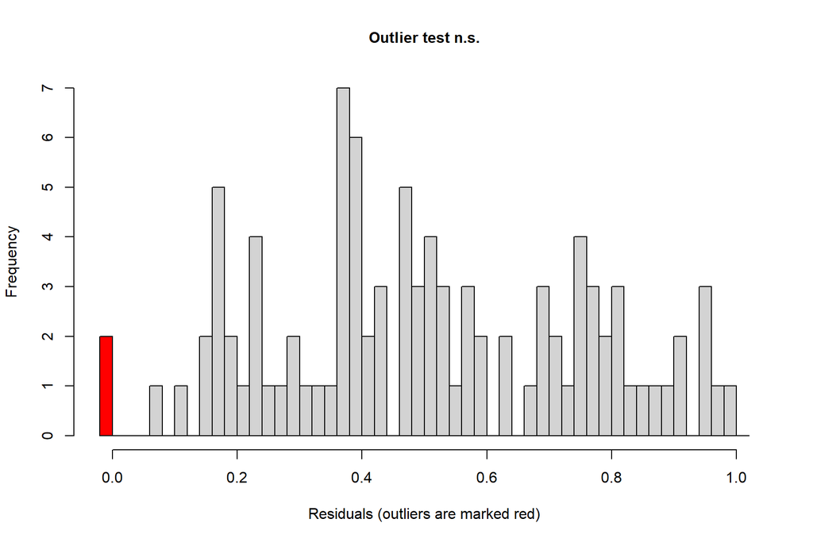

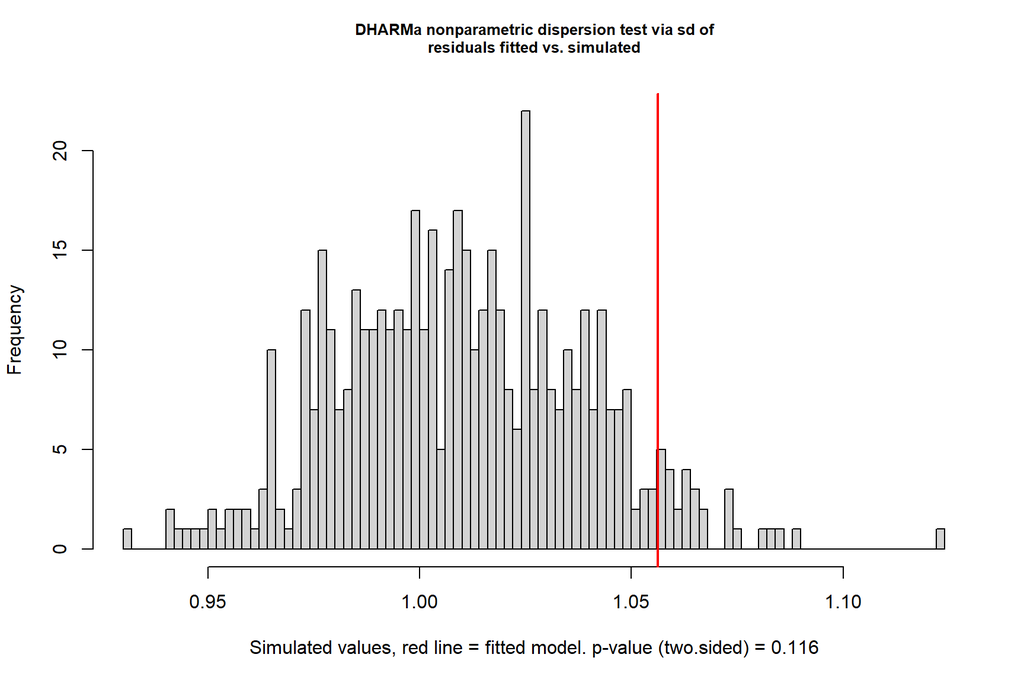

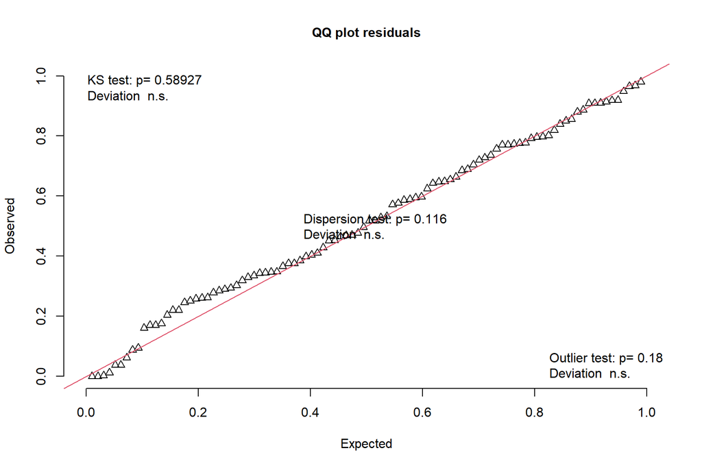

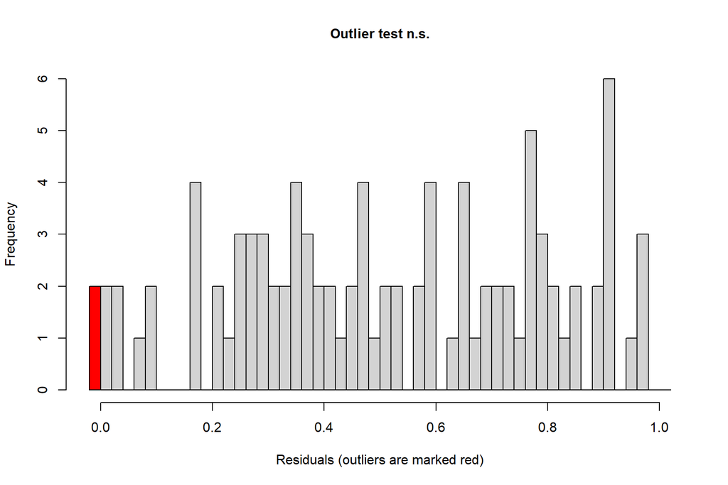

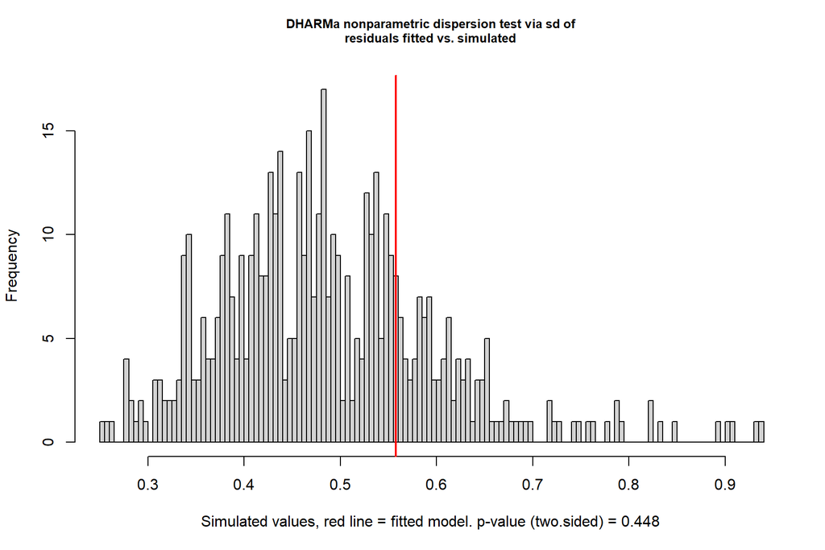

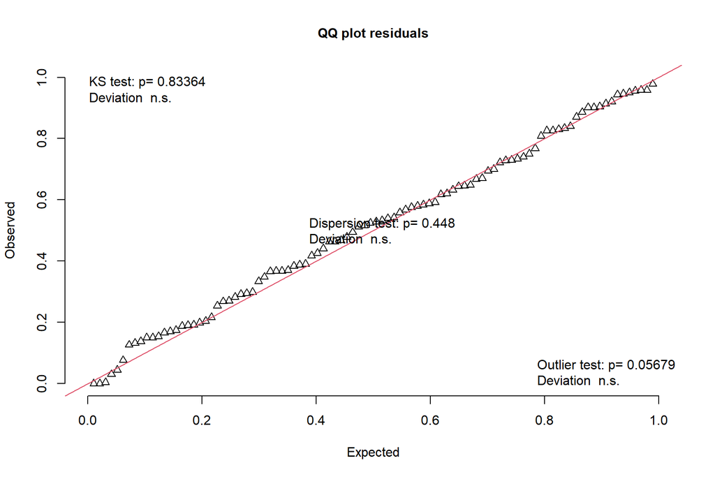

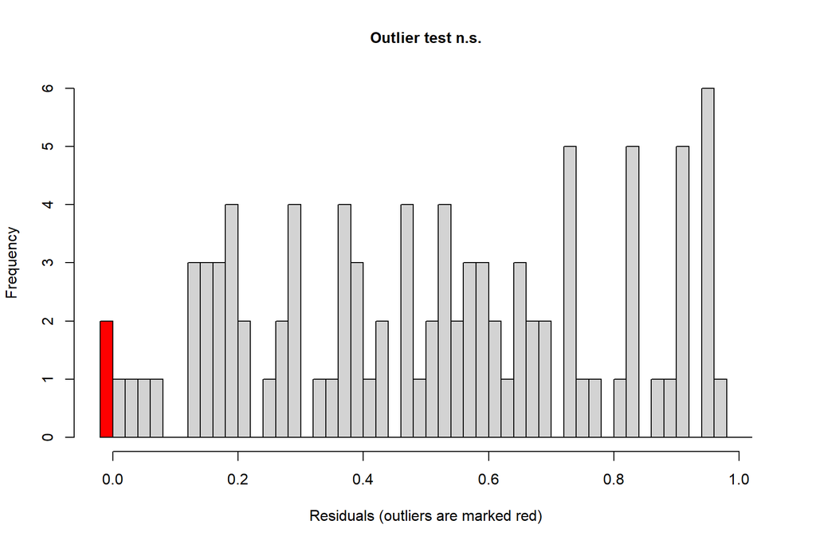

```r
kable(diag_tab,
      caption = "DHARMa residual diagnostics. Small p-values indicate lack-of-fit (over/under-dispersion, non-uniform residuals, or outliers).",
      align = c("l", "r", "r", "r"))
```

DHARMa residual diagnostics. Small p-values indicate lack-of-fit (over/under-dispersion, non-uniform residuals, or outliers).

[output not shown]

The diagnostics are acceptable overall. The total-weight QQ plot shows mild tail deviation (uniformity p = 0.048), and the healthy-weight outlier test is borderline (p = 0.057); the other dispersion and uniformity tests are clean. The log transformation removes the mean–variance funnel that a Gaussian model on the raw weight scale would show, and the treatment-specific beta/beta-binomial dispersion accounts for the fact that control percentages are close to the ceiling and much less variable than heat-treated percentages.

The pair random effect is important for the weights: the intraclass correlation is 0.17 for total weight and 0.10 for healthy weight, so the two plots in a pair are not independent. For the percentage outcomes the pair variance is small once the treatment-specific dispersion is included; the dispersion term, rather than the pair intercept, captures most of the extra-binomial variation. The design is still respected because treatment varies within pair and the fixed-effect treatment contrast is a within-pair comparison.

# Sensitivity analyses

```r
# 1. Gamma GLMM instead of log-normal for the weight outcomes.
gamma_total <- glmmTMB(
  total_weight ~ treatment * (intensity_group + cultivar + year) +
    year:cultivar + (1 | pair),
  data = d, family = Gamma(link = "log")
)
gamma_healthy <- glmmTMB(
  healthy_weight ~ treatment * (intensity_group + cultivar + year) +
    year:cultivar + (1 | pair),
  data = d, family = Gamma(link = "log")
)

gamma_row <- function(fit, response) {
  s <- as.data.frame(summary(emmeans(fit, ~ treatment, type = "response")))
  data.frame(
    Model = "Gamma GLMM",
    Response = response,
    Control = sprintf("%.0f", s$response[1]),
    OTC = sprintf("%.0f", s$response[2]),
    stringsAsFactors = FALSE
  )
}

# 2. Binomial GLMM with an observation-level random effect for the count percentage.
d$obs <- factor(seq_len(nrow(d)))
bin_count <- glmmTMB(
  cbind(healthy_n, rotten_n) ~ treatment * (intensity_group + cultivar + year) +
    year:cultivar + (1 | pair) + (1 | obs),
  data = d, family = binomial(link = "logit")
)

# 3. Drop the most extreme healthy-weight plot (2025 MQ A OTC plot 2).
d_drop <- d[!(d$year == "2025" & d$cultivar == "MQ" &
              d$intensity_group == "A" & d$treatment == "OTC" & d$plot == 2), ]
fit_healthy_drop <- lmer(
  log(healthy_weight) ~ treatment * (intensity_group + cultivar + year) +
    year:cultivar + (1 | pair),
  data = d_drop, REML = TRUE
)
drop_ratio <- as.data.frame(confint(contrast(
  emmeans(fit_healthy_drop, ~ treatment), "revpairwise", type = "response"
)))
drop_p <- as.data.frame(summary(contrast(
  emmeans(fit_healthy_drop, ~ treatment), "revpairwise", type = "response"
)))$p.value

sens_tab <- bind_rows(
  gamma_row(gamma_total,   "Total weight (g)"),
  gamma_row(gamma_healthy, "Healthy weight (g)")
)

kable(sens_tab,
      caption = "Sensitivity check: Gamma GLMM marginal means for the weight outcomes.",
      align = c("l", "l", "r", "r"))
```

Sensitivity check: Gamma GLMM marginal means for the weight outcomes.

| Model | Response | Control | OTC |
| --- | --- | --- | --- |
| Gamma GLMM | Total weight (g) | 812 | 724 |
| Gamma GLMM | Healthy weight (g) | 793 | 647 |

```r
cat(sprintf("Healthy-weight ratio after dropping the most extreme plot: %.3f (%.3f, %.3f), p = %s.\n",
            drop_ratio$ratio, drop_ratio$lower.CL, drop_ratio$upper.CL,
            fmt_p(drop_p)))
```

```
Healthy-weight ratio after dropping the most extreme plot: 0.816 (0.764, 0.872), p = <0.001.
```

# Discussion and limitations

**Answers to the scientific questions.**

1. **Total weight**: heat stress reduced total fruit weight by about 11% (808 → 715 g). The effect grows with the number of pulses; the 4-pulse treatment reduced total weight by about 25%.
2. **Healthy weight**: heat stress reduced healthy fruit weight by about 20% (789 → 634 g), the largest absolute effect. The effect also grows with the number of pulses, reaching about −30% at 4 pulses.
3. **Healthy percentage by count**: heat stress reduced the healthy count percentage by about 12 percentage points (95.4% → 83.2%). The effect is already large at one pulse and does not increase much with additional pulses.
4. **Healthy percentage by weight**: heat stress reduced the healthy weight percentage by about 9 percentage points (98.0% → 89.3%), with a similar pattern.
5. **Cultivar, year, intensity**: the weight effect was larger in MQ than in ST, but cultivar is confounded with field. There was no strong evidence that the heat effect differed between 2024 and 2025. Pulse intensity mattered for the weight outcomes (dose–response) but not for the percentage outcomes; the percentage loss appears to be a step change caused by any heat pulse.

**Why the weights and percentages tell different stories.** Total and healthy weight combine berry number and berry size, whereas the percentages measure rot incidence. The data suggest that even a single pulse is enough to raise rot incidence by a similar amount, while additional pulses mainly reduce berry size/healthy weight. This is biologically plausible but should be treated as a hypothesis: the experiment has three pairs per cell, and the pulse schedules differ across A–D (the A plots receive pulses earlier and more often), so “intensity” is not a perfectly clean dose.

**Limitations.**

- **Cultivar is confounded with field.** Each cultivar is grown in a different field, so the MQ–ST difference cannot be attributed to variety alone.
- **Year is confounded with weather and season.** The year effect is a baseline difference, not a causal weather effect; the large 2025 ST decline is consistent with a field/season effect.
- **Pulse timing differs across A–D.** A (4 pulses) starts earlier and is pulsed more often than D (1 pulse); the intensity contrast therefore mixes frequency, timing, and total heat dose.
- **Control plots are not untreated.** Control plots have insulated OTCs without heat lamps during the pulse windows, so the treatment contrast includes the chamber structure (and possibly slight temperature/moisture differences), not only the heat lamps.
- **Small replication for interactions.** Three pairs per cell give limited power for three-way interactions and for the by-intensity contrasts; the non-significant interactions should not be read as evidence of no effect.
- **Four correlated outcomes.** The outcomes are computed from the same fruit and are not independent; the report interprets effect sizes and CIs rather than a strict family-wise error rate.
- **Total weight includes rotten fruit.** It is not marketable yield; healthy weight is the better yield measure.

**Overall conclusion.** Acute heat pulses reduced both the quantity and the quality of the cranberry harvest. The healthy-weight loss (about 20%) was larger than the total-weight loss (about 11%) because heat increased rotten weight. The weight loss increased with the number of heat pulses, while the healthy percentage dropped sharply even at one pulse and then stayed roughly constant. These results are consistent with the concern that more frequent severe heat spells would increase fruit rot and lower cranberry yields, but the observational confounding (cultivar/field, year/season, pulse timing) means the magnitudes should be interpreted as experiment-specific estimates rather than universal heat-response coefficients.

# Methods references

- Bates, D., Mächler, M., Bolker, B., & Walker, S. (2015). Fitting linear mixed-effects models using lme4. *Journal of Statistical Software*, 67(1).
- Brooks, M. E., et al. (2017). glmmTMB balances speed and flexibility among packages for zero-inflated generalized linear mixed modeling. *The R Journal*, 9(2).
- Lenth, R. V. (2024). *emmeans: Estimated marginal means, aka least-squares means*. R package.
- Hartig, F. (2024). *DHARMa: Residual diagnostics for hierarchical (multi-level / mixed) regression models*. R package.